# Twitter Analytics - Arctic Data Centert

## Arctic Data Center Twitter Metrics

This report contains information about the Arctic Data Center’s Twitter account, @ArcticDataCtr, and how effective it is at engaging a wider audience of Arctic researchers, students, and other data organizations.

### Data Collection - Summary

Data was collected manually on the first of the month from https://analytics.twitter.com/user/arcticdatactr/home. This summary file contains:

- month: month of Tweet information
- year: year of Tweet information
- tweets: number of Tweets that month
- profile-visits: number of times users visited the @ArcticDataCtr profile page
- new-followers: number of new followers gained (gross new followers; does not account for followers lost)
- tweet-impressions: number of times users are served @ArcticDataCtr tweets in timeline, search results, or from the profile
- mentions: number of times @ArcticDataCtr was mentioned in tweets
- number-followers: number of followers, manually copied from https://twitter.com/arcticdatactr.
  - Number of followers is the only piece of data in this file that is only available from Twitter at the time you access the site i.e. it is not made available with the rest of the data in this dataset. Thus, there are NAs for dates prior to the time I started to collect this data or for dates before I realized this data was ephemeral.

### Data Collection - Monthly Tweets

Data was scraped using the R package rtweet. This data contains the following parameters:

- Tweet ID: the identifier for the Tweet, which can be used to find the permanent URL
- Tweet permalink: permanent URL for the Tweet
- Tweet text: the text (content) of the Tweet
- time: the time the Tweet was sent (GMT)
- impressions: number of times users are served the tweet in timeline, search results, or from the @ArcticDataCtr profile
- engagements: total number of times a user interacted with a Tweet. Clicks anywhere on the Tweet, including Retweets, replies, follows, likes, links, cards, hashtags, embedded media, username, profile photo, or Tweet expansion
- engagement rate: number of engagements divided by impressions
- retweets: number of times that Tweet was retweeted
- replies: number of replies that Tweet generated
- user profile clicks: number of times a user clicked on the @ArcticDataCtr profile from that particular tweet
- URL clicks: number of times that URL within the tweet was clicked
- hashtag clicks: number of times any of your hashtags were clicked from that tweet
- detail expands: number of times users clicked ‘see more’ on your tweet
- permalink clicks: clicks on the Tweet permalink
- follows: times a user followed you directly from the Tweet
- email tweet: number of times the Tweet is shared by email
- media views: number of times media attached to the Tweet is viewed
- media engagements: an interaction on a tweet that has a piece of media (photo, vine, other video, etc) in it

Other metrics that are collected are all about promoted views, etc. which the Arctic Data Center doesn’t use, and as such those were excluded from the analysis.

## Summary Information

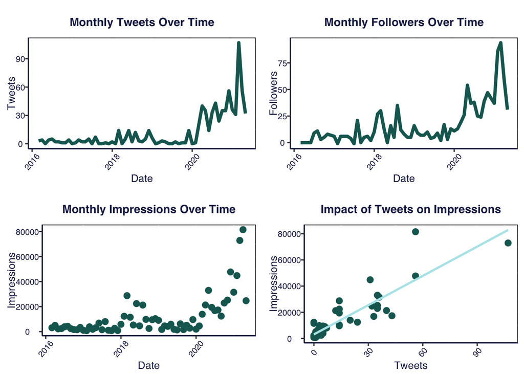

#### Top 10: Most Liked Tweets

| Tweet | Date and Time | Likes | Retweets | Hashtags Used |
| --- | --- | --- | --- | --- |
| We are excited to announce that we have been funded for another 5 years! The @NSF @arcticdatactr is honored to serve the #Arctic research community to preserve all #data, #metadata, software, media, i… | 2021-05-26 17:04:21 | 51 | 5 | Arctic, data, metadata |
| Happening right now! @nceas is hosting @1NativeSoilNerd as she gives her talk titled: #Indigenous Data Sovereignty: How Scientists and Researchers can Empower Data Governance. Join the Zoom #webinar: … | 2021-04-07 19:06:59 | 38 | 16 | Indigenous, webinar |
| New tool: @NSIDC is making #Greenland exploration accessible to all with #QGreenland! https://t.co/Rg0zaa1D64 Anyone can use it to see data about Greenland’s landscape, ecosystem, & communities. Plus,… | 2021-02-24 17:28:03 | 30 | 15 | Greenland, QGreenland, data |
| New feature alert! #Arctic #researchers can now create a portal with @arcticdatactr to see #data from across the #catalog all in one place. Each #portal can be branded with logos and colors and has a … | 2020-05-05 16:30:23 | 28 | 10 | Arctic, researchers, data, catalog, portal |
| Calling educators who love data - do you need tools to teach about #glaciers? The Open Global Glacier Model has interactive apps, graphics, interactive notebooks, and tutorials for you! #STEMeducation… | 2021-02-10 21:52:03 | 26 | 17 | glaciers, STEMeducation, ArcticEducation, DataEducation, LoveDataWeek |
| Next up - a thread of takeaways from Learning from #Indigenous Methodologies in Collaborative #Arctic Science! A pre-emptive thank you to all the presenters sharing their experiences. #ASSW2021 | 2021-03-24 16:35:02 | 23 | 8 | Indigenous, Arctic, ASSW2021 |
| For #SharingSciFri, we’re highlighting a pioneer in #Arctic exploration: Matthew Henson, who was the first Black man to reach the #NorthPole! Read more about his legacy and his role in exploration fro… | 2020-06-05 14:28:02 | 22 | 14 | SharingSciFri, Arctic, NorthPole, BlackinSTEM |
| Anxiously awaiting the next #dataset highlight? Now it’s live! We’re excited to highlight @rosem36 & her team researching DOC along the Kuparuk River. Learn about the importance of their #data & disco… | 2018-04-10 19:11:36 | 20 | 8 | dataset, data, Arctic |
| #MovieMonday: Experience the #Arctic with an Award-Winning @MOSAiCArctic Film! Immerse yourself in Drifting North: Into the Polar Night (25 minutes). https://t.co/E81gnsBbLy https://t.co/AUF5TfzQXP | 2021-04-26 15:18:02 | 19 | 8 | MovieMonday, Arctic |
| Reaching out to the biodiversity community with repository management best practices and lessons learned from the Arctic Data Center #digidata @i_steves https://t.co/b9djUYuxiP | 2018-06-04 22:46:53 | 19 | 3 | digidata |

#### Top 10: Most Retweeted Tweets

| Tweet | Date and Time | Likes | Retweets | Hashtags Used |
| --- | --- | --- | --- | --- |
| Calling educators who love data - do you need tools to teach about #glaciers? The Open Global Glacier Model has interactive apps, graphics, interactive notebooks, and tutorials for you! #STEMeducation… | 2021-02-10 21:52:03 | 26 | 17 | glaciers, STEMeducation, ArcticEducation, DataEducation, LoveDataWeek |
| Happening right now! @nceas is hosting @1NativeSoilNerd as she gives her talk titled: #Indigenous Data Sovereignty: How Scientists and Researchers can Empower Data Governance. Join the Zoom #webinar: … | 2021-04-07 19:06:59 | 38 | 16 | Indigenous, webinar |
| Calling all #Arctic researchers: Want to improve your #data management skills & learn ways to implement #DataScience tools in your work? Join us & your arctic colleagues @nceas in August for our 2018 … | 2018-03-15 17:27:58 | 12 | 16 | Arctic, data, DataScience |
| We’re looking for input from educators who teach or want to teach #Arctic science! #STEMeducation #AcademicChatter #edchat To what extent do you need Arctic #data-focused educational materials for you… | 2020-05-26 22:05:13 | 10 | 16 | Arctic, STEMeducation, AcademicChatter, edchat, data |
| New tool: @NSIDC is making #Greenland exploration accessible to all with #QGreenland! https://t.co/Rg0zaa1D64 Anyone can use it to see data about Greenland’s landscape, ecosystem, & communities. Plus,… | 2021-02-24 17:28:03 | 30 | 15 | Greenland, QGreenland, data |
| We’re hiring! Support the @arcticdatactr and other @nceas projects in building community, supporting Arctic research and promoting open science and data reuse. Community Engagement and Outreach Coordi… | 2019-05-09 18:24:57 | 11 | 15 | NA |
| For #SharingSciFri, we’re highlighting a pioneer in #Arctic exploration: Matthew Henson, who was the first Black man to reach the #NorthPole! Read more about his legacy and his role in exploration fro… | 2020-06-05 14:28:02 | 22 | 14 | SharingSciFri, Arctic, NorthPole, BlackinSTEM |
| #Job announcement - The Arctic Data Center and @nceas are looking for Data Fellows! UCSB is an EOE, including disability/vets. https://t.co/CKVhTxldUr | 2020-02-20 23:29:28 | 11 | 11 | Job |
| Calling #Arctic researchers - Do your research data management skills need refreshing? Want to work in a more open, efficient and reproducible way? Apply by August 15th to join our funded Data Science… | 2019-08-01 17:46:23 | 10 | 11 | Arctic |
| #opportunity alert! @JuneauIcefield is accepting applications for students, staff, and faculty for the 2021 JIRP Field Season. All applications are due on January 31st & more information can be found … | 2021-01-14 18:49:49 | 6 | 11 | opportunity |

#### Distribution of replies, retweets, and organic tweets

Analyzing the ratio of replies, retweets and organic tweets can tell you a great deal about the type of account you’re analysing. No one likes a Twitter account that exclusively retweets for instance, without any individual content. Finding a good ratio of replies, retweets and organic tweets is therefore a key metric to monitor if one wishes to improve the performance of an account.

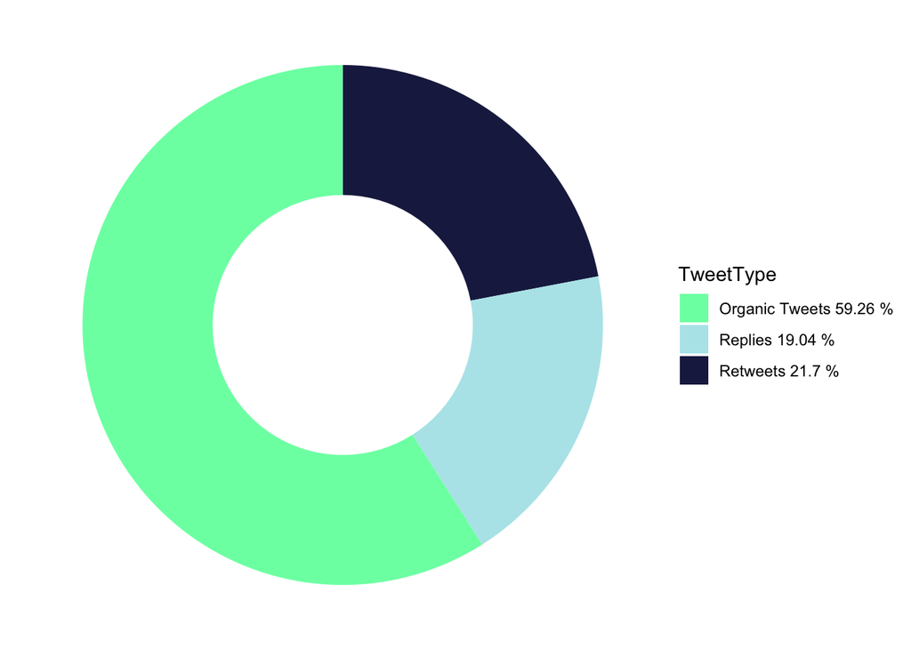

### Tweet Text Analysis

Bar graph illustrating the 15 most commonly tweeted words in @ArcticDataCtr’s tweets, with common stop words removed from the list.

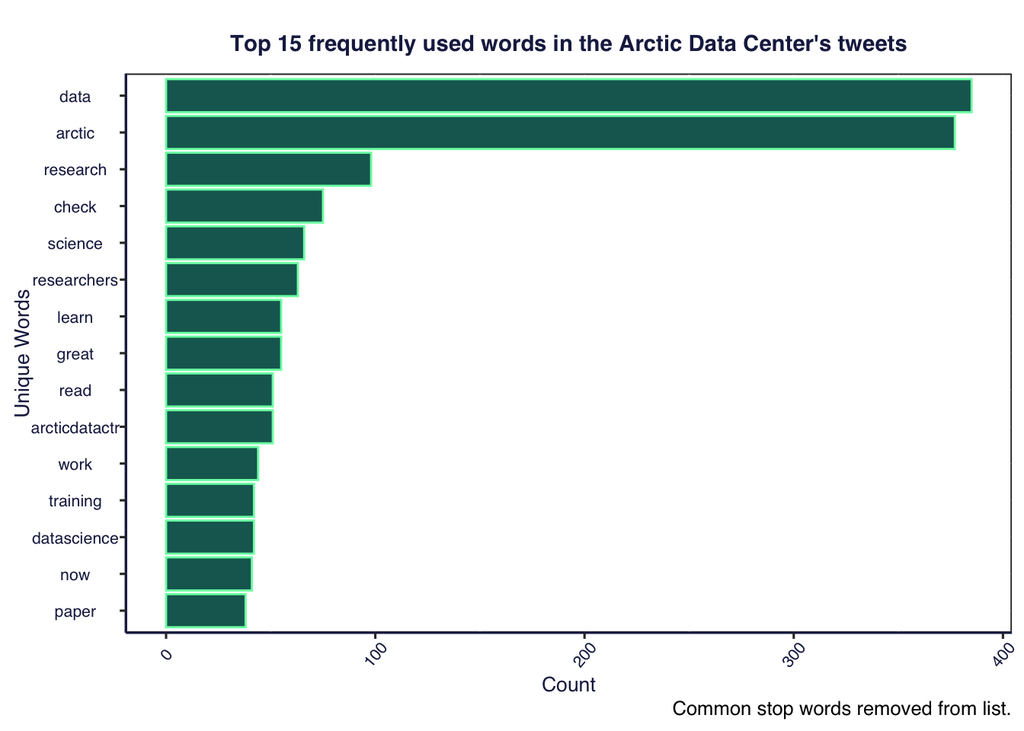

### Showing the most frequently used hashtags

Hashtags used more than 5 times are displayed in the wordcloud below.

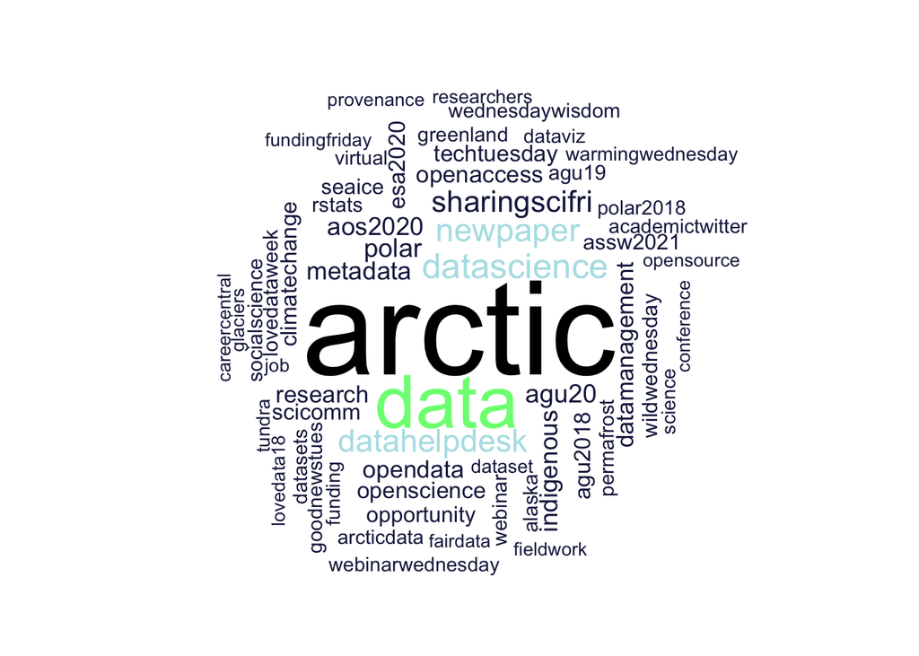

### Understanding what accounts we frequently retweet

Accounts retweeted more than 3 times are displayed in the wordcloud below.

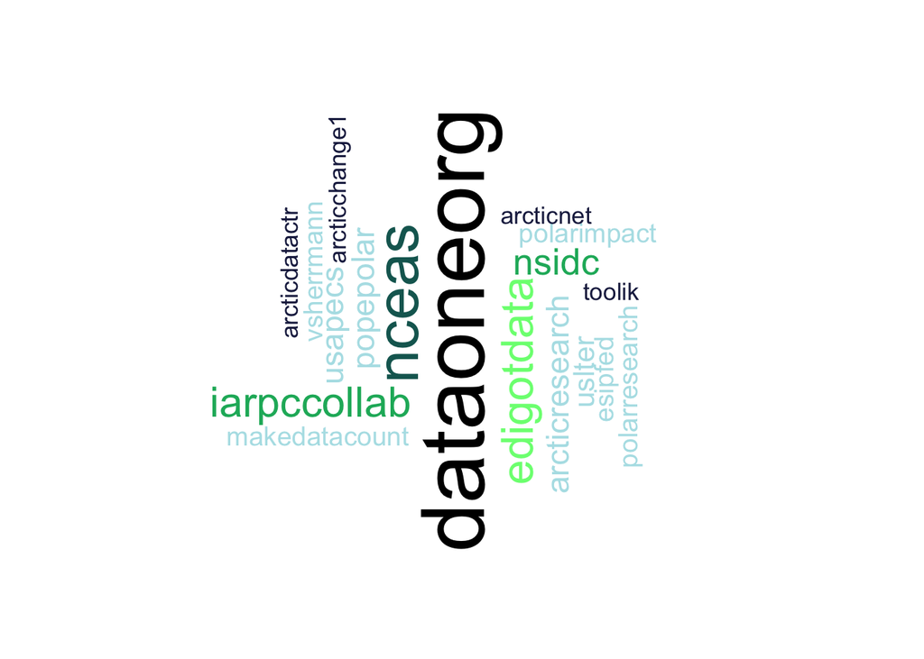

### Understanding the sentiment of tweet content

No one likes a Twitter account that only spreads angry or sad tweets. Capturing the tone of your tweets and how they balance out is a good indication of your account’s performance.

There are short comings as well like conflation deficiency that is the inability to discriminate among different meanings of a word. For example, the word “bat” has at least two distinct meanings: a flying animal, and a piece of sporting equipment. Another challenge is a text may contain multiple sentiments all at once.

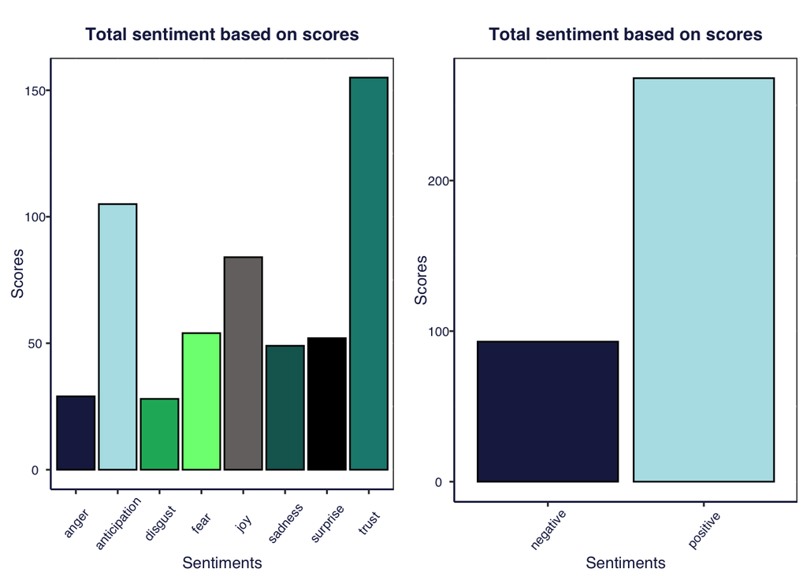